## Object Detection On Command

# Seyeon Lee

### September 12th, 2019

### Overview

Object Detection technology is a subpart of Computer Vision study that localizes and classifies an object on an image. This project will explore YOLO algorithm with Resnet50 using transfer learning, a method to use a pre-trained neural network and adapt the model to perform different tasks with different dataset. PASCAL VOC (Visual Object Classes) 2012 dataset will be in use of training models.

### Contents

- Step 0: Understand PASCAL VOC 2012 Data
- Step 1: Data Pre-processing
- Step 2: Batch Generator
- Step 3: Model Architecture
- Step 4: Loss Function
- Step 5: Training
- Step 6: Evaluation
- Step 7: Work Cited

## Step 0: Understand PASCAL VOC 2012 Data

### Combining annotation files into one CSV file

PASCAL VOC 2012 dataset has corresponding .xml file with annotation for each image jpg file. Due to its complexity, we need to combine all these .xml files into one single csv file via panda modules.

First, let's sort all these xml files into one table.

```python
anno_dir = "/home/ubuntu/VOCdevkit/VOC2012/Annotations/"
img_dir  = "/home/ubuntu/VOCdevkit/VOC2012/JPEGImages/"
```

```python
import os
import numpy as np
import xml.etree.ElementTree as ET
from collections import OrderedDict
import matplotlib.pyplot as plt
import pandas as pd

def extracting_xml(tree):
    objN = 0
    row  = OrderedDict()
    for lines in tree.iter():

        if lines.tag == "size":
            for elem in lines:
                row[elem.tag] = int(elem.text)

        if lines.tag == "object":
            for elem in lines:
                if elem.tag == "name":
                    row["bbx_{}_{}".format(objN,elem.tag)] = str(elem.text)
                if elem.tag == "bndbox":
                    for i in elem:
                        row["bbx_{}_{}".format(objN,i.tag)] = float(i.text)
                    objN += 1
    row["objN"] = objN
    return(row)

df_anno = []
for filename in os.listdir(anno_dir):
    if not filename.startswith('.'): ## avoid hidden folders and files
        tree = ET.parse(os.path.join(anno_dir,filename))
        row = extracting_xml(tree)
        row["fileID"] = filename.split(".")[0]
        df_anno.append(row)
df_anno = pd.DataFrame(df_anno)

maxobjN = np.max(df_anno["objN"])

df_anno.head()
```

|  | width | height | depth | bbx_0_name | bbx_0_xmin | bbx_0_ymin | bbx_0_xmax | bbx_0_ymax | bbx_1_name | bbx_1_xmin | ... | bbx_54_name | bbx_54_xmin | bbx_54_ymin | bbx_54_xmax | bbx_54_ymax | bbx_55_name | bbx_55_xmin | bbx_55_ymin | bbx_55_xmax | bbx_55_ymax |
| --- | --- | --- | --- | --- | --- | --- | --- | --- | --- | --- | --- | --- | --- | --- | --- | --- | --- | --- | --- | --- | --- |
| 0 | 500 | 375 | 3 | person | 11.0 | 121.0 | 161.0 | 375.0 | person | 38.0 | ... | NaN | NaN | NaN | NaN | NaN | NaN | NaN | NaN | NaN | NaN |
| 1 | 500 | 336 | 3 | person | 212.0 | 101.0 | 351.0 | 336.0 | person | 322.0 | ... | NaN | NaN | NaN | NaN | NaN | NaN | NaN | NaN | NaN | NaN |
| 2 | 500 | 386 | 3 | dog | 170.0 | 138.0 | 339.0 | 271.0 | chair | 1.0 | ... | NaN | NaN | NaN | NaN | NaN | NaN | NaN | NaN | NaN | NaN |
| 3 | 373 | 500 | 3 | bird | 130.0 | 132.0 | 258.0 | 320.0 | NaN | NaN | ... | NaN | NaN | NaN | NaN | NaN | NaN | NaN | NaN | NaN | NaN |
| 4 | 329 | 500 | 3 | person | 101.0 | 175.0 | 249.0 | 325.0 | NaN | NaN | ... | NaN | NaN | NaN | NaN | NaN | NaN | NaN | NaN | NaN | NaN |

5 rows × 285 columns

Save the table as a csv file.

```python
# location to save df_anno.csv
csv_location = "/home/ubuntu/VOCdevkit/VOC2012"
df_anno.to_csv(os.path.join(csv_location,"df_anno.csv"),index=False)
```

### Setting the training - validation set

Training - Validation dataset is provided by PASCAL VOC 2012 datset.  
We're just going to read in the list of image file names.

Since each class has different number of data, the number of images in training and validation dataset does not represent the ratio of training - validation data.

```
Number of training images: 5717
Number of valid images: 5824
Number of trainval images: 11541

Example image:
height: 442  width: 500  color: 3
```

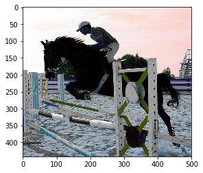

```python
import cv2
import matplotlib.pyplot as plt

train_image_dir = "/home/ubuntu/VOCdevkit/VOC2012/ImageSets/Main/train.txt"
val_image_dir = "/home/ubuntu/VOCdevkit/VOC2012/ImageSets/Main/val.txt"
trainval_image_dir = "/home/ubuntu/VOCdevkit/VOC2012/ImageSets/Main/trainval.txt"
train_image_fnm = open(train_image_dir,"r").read().split('\n')
train_image_fnm.pop() #somehow, the last element is empty
val_image_fnm = open(val_image_dir,"r").read().split('\n')
trainval_image_fnm = open(trainval_image_dir,"r").read().split('\n')
print("Number of training images:", len(train_image_fnm))
print("Number of valid images:", len(val_image_fnm))
print("Number of trainval images:", len(trainval_image_fnm))
print(" ")
print("Example image:")

img=cv2.imread(img_dir + train_image_fnm[0]+".jpg")
h, w, c = img.shape
print ("height:",h," width:", w," color:", c)
plt.imshow(img)
plt.show()
```

### Achieving test data

In order to receive test data for PASCAL VOC 2012 Challenge, you need to go to [this site](http://host.robots.ox.ac.uk/pascal/VOC/voc2012/#testdata)

Here, you have to register and download the test data in a .tar form. After un-tarring this file (refer to ReadMe.md), place the folder in your VOC Devkit folder.

## Step 1: Data Pre-processing

### Rescaling images to 208 * 208

CNN reads in pre-specified shape of images. For each image input, no matter what size they portrait, they will be encoded into (208, 208, 3). Meaning, they will be input as a form of 208 * 208 pixels with color. Parameters xmin, xmax, ymin, and ymax will be adjusted accordingly.

```
height: 208  width: 208  color: 3
```

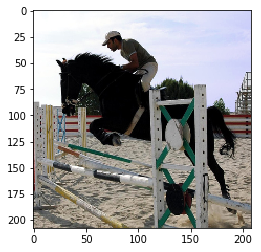

```python
def rescale_img(new_h, new_w, path):
    image=cv2.imread(path)
    image=cv2.resize(image,(new_h, new_w))
    image = image[:,:,::-1] #re-ordering rgb
    image = image/255 #normalizing

    return image

new_h = 208 #new height of the resized image
new_w = 208 #new width of the resized image


path = img_dir + train_image_fnm[0]+".jpg"
image = rescale_img(new_h, new_w, path)


h, w, c = image.shape
print ("height:",h," width:", w," color:", c)
plt.imshow(image)
plt.show()
```

### Creating another dataframe with rescaled images

```python
rescaled_anno = df_anno.copy()
rescaled_anno.head()
```

|  | width | height | depth | bbx_0_name | bbx_0_xmin | bbx_0_ymin | bbx_0_xmax | bbx_0_ymax | bbx_1_name | bbx_1_xmin | ... | bbx_54_name | bbx_54_xmin | bbx_54_ymin | bbx_54_xmax | bbx_54_ymax | bbx_55_name | bbx_55_xmin | bbx_55_ymin | bbx_55_xmax | bbx_55_ymax |
| --- | --- | --- | --- | --- | --- | --- | --- | --- | --- | --- | --- | --- | --- | --- | --- | --- | --- | --- | --- | --- | --- |
| 0 | 500 | 375 | 3 | person | 11.0 | 121.0 | 161.0 | 375.0 | person | 38.0 | ... | NaN | NaN | NaN | NaN | NaN | NaN | NaN | NaN | NaN | NaN |
| 1 | 500 | 336 | 3 | person | 212.0 | 101.0 | 351.0 | 336.0 | person | 322.0 | ... | NaN | NaN | NaN | NaN | NaN | NaN | NaN | NaN | NaN | NaN |
| 2 | 500 | 386 | 3 | dog | 170.0 | 138.0 | 339.0 | 271.0 | chair | 1.0 | ... | NaN | NaN | NaN | NaN | NaN | NaN | NaN | NaN | NaN | NaN |
| 3 | 373 | 500 | 3 | bird | 130.0 | 132.0 | 258.0 | 320.0 | NaN | NaN | ... | NaN | NaN | NaN | NaN | NaN | NaN | NaN | NaN | NaN | NaN |
| 4 | 329 | 500 | 3 | person | 101.0 | 175.0 | 249.0 | 325.0 | NaN | NaN | ... | NaN | NaN | NaN | NaN | NaN | NaN | NaN | NaN | NaN | NaN |

5 rows × 285 columns

### Adjust the bounding boxes accordingly

```python
for N in range(0,maxobjN):
    for cr in ['xmin', 'xmax']:
        self = rescaled_anno["bbx_{}_{}".format(N,cr)].copy()
        rescaled_anno["bbx_{}_{}".format(N,cr)] = self * new_w / df_anno["width"]
    for cr in ['ymin', 'ymax']:
        self = rescaled_anno["bbx_{}_{}".format(N,cr)].copy()
        rescaled_anno["bbx_{}_{}".format(N,cr)] = self * new_h / df_anno["height"]

rescaled_anno["width"] = new_w
rescaled_anno["height"] = new_h
rescaled_anno.head()
```

|  | width | height | depth | bbx_0_name | bbx_0_xmin | bbx_0_ymin | bbx_0_xmax | bbx_0_ymax | bbx_1_name | bbx_1_xmin | ... | bbx_54_name | bbx_54_xmin | bbx_54_ymin | bbx_54_xmax | bbx_54_ymax | bbx_55_name | bbx_55_xmin | bbx_55_ymin | bbx_55_xmax | bbx_55_ymax |
| --- | --- | --- | --- | --- | --- | --- | --- | --- | --- | --- | --- | --- | --- | --- | --- | --- | --- | --- | --- | --- | --- |
| 0 | 208 | 208 | 3 | person | 4.576000 | 67.114667 | 66.976000 | 208.000000 | person | 15.808 | ... | NaN | NaN | NaN | NaN | NaN | NaN | NaN | NaN | NaN | NaN |
| 1 | 208 | 208 | 3 | person | 88.192000 | 62.523810 | 146.016000 | 208.000000 | person | 133.952 | ... | NaN | NaN | NaN | NaN | NaN | NaN | NaN | NaN | NaN | NaN |
| 2 | 208 | 208 | 3 | dog | 70.720000 | 74.362694 | 141.024000 | 146.031088 | chair | 0.416 | ... | NaN | NaN | NaN | NaN | NaN | NaN | NaN | NaN | NaN | NaN |
| 3 | 208 | 208 | 3 | bird | 72.493298 | 54.912000 | 143.871314 | 133.120000 | NaN | NaN | ... | NaN | NaN | NaN | NaN | NaN | NaN | NaN | NaN | NaN | NaN |
| 4 | 208 | 208 | 3 | person | 63.854103 | 72.800000 | 157.422492 | 135.200000 | NaN | NaN | ... | NaN | NaN | NaN | NaN | NaN | NaN | NaN | NaN | NaN | NaN |

5 rows × 285 columns

### Visualization of rescaled images

Here, I will show how bounding boxes have resized and relocated according to newly scaled images.

```python
import imageio
def plt_rectangle(plt,label,x1,y1,x2,y2):

    linewidth = 1
    color = "red"
    plt.text(x1,y1,label,fontsize=10,backgroundcolor="cyan")
    plt.plot([x1,x1],[y1,y2], linewidth=linewidth,color=color)
    plt.plot([x2,x2],[y1,y2], linewidth=linewidth,color=color)
    plt.plot([x1,x2],[y1,y1], linewidth=linewidth,color=color)
    plt.plot([x1,x2],[y2,y2], linewidth=linewidth,color=color)




plt.imshow(image) # plot image
df = rescaled_anno.loc[rescaled_anno['fileID']==train_image_fnm[0]]
row_num = int(df.index.values)
print(row_num)
df.head()
```

```
870
```

|  | width | height | depth | bbx_0_name | bbx_0_xmin | bbx_0_ymin | bbx_0_xmax | bbx_0_ymax | bbx_1_name | bbx_1_xmin | ... | bbx_54_name | bbx_54_xmin | bbx_54_ymin | bbx_54_xmax | bbx_54_ymax | bbx_55_name | bbx_55_xmin | bbx_55_ymin | bbx_55_xmax | bbx_55_ymax |
| --- | --- | --- | --- | --- | --- | --- | --- | --- | --- | --- | --- | --- | --- | --- | --- | --- | --- | --- | --- | --- | --- |
| 870 | 208 | 208 | 3 | horse | 22.048 | 40.941176 | 195.936 | 197.647059 | person | 65.728 | ... | NaN | NaN | NaN | NaN | NaN | NaN | NaN | NaN | NaN | NaN |

1 rows × 285 columns

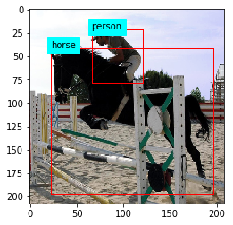

```python
plt.imshow(image) # plot image

# for each object in the image, plot the bounding box
for iplot in range(df.at[row_num,"objN"]):
    plt_rectangle(plt,
                  label = df.at[row_num,"bbx_{}_name".format(iplot)],
                  x1=df.at[row_num,"bbx_{}_xmin".format(iplot)],
                  y1=df.at[row_num,"bbx_{}_ymin".format(iplot)],
                  x2=df.at[row_num,"bbx_{}_xmax".format(iplot)],
                  y2=df.at[row_num,"bbx_{}_ymax".format(iplot)])
plt.show() ## show the plot
```

### Bounding Box Encoding

So far, we have been plotting out bounding boxes based on the coordinates provided by the PASCAL VOC 2012 dev kit, which is formatted as below:  
**{bbx_n_name,bbx_n_xmin,bbx_n_ymin,bbx_n_xmax,bbx_n_ymax}**

[figure not shown]

Let's rename the coulmn names first!

```python
transformed_anno = rescaled_anno.copy()
#old column names
old_col_nms_xmin=[]
old_col_nms_ymin=[]
old_col_nms_xmax=[]
old_col_nms_ymax=[]
#new column names
new_col_nms_xmin=[]
new_col_nms_ymin=[]
new_col_nms_xmax=[]
new_col_nms_ymax=[]

for i in range(maxobjN):
    old_col_nms_xmin.append("bbx_{}_xmin".format(i))
    old_col_nms_ymin.append("bbx_{}_ymin".format(i))
    old_col_nms_xmax.append("bbx_{}_xmax".format(i))
    old_col_nms_ymax.append("bbx_{}_ymax".format(i))
    new_col_nms_xmin.append("bbx_{}_center_x".format(i))
    new_col_nms_ymin.append("bbx_{}_center_y".format(i))
    new_col_nms_xmax.append("bbx_{}_center_w".format(i))
    new_col_nms_ymax.append("bbx_{}_center_h".format(i))

transformed_anno.rename(columns=dict(zip(old_col_nms_xmin, new_col_nms_xmin)), inplace=True)
transformed_anno.rename(columns=dict(zip(old_col_nms_ymin, new_col_nms_ymin)), inplace=True)
transformed_anno.rename(columns=dict(zip(old_col_nms_xmax, new_col_nms_xmax)), inplace=True)
transformed_anno.rename(columns=dict(zip(old_col_nms_ymax, new_col_nms_ymax)), inplace=True)


transformed_anno.head()
```

|  | width | height | depth | bbx_0_name | bbx_0_center_x | bbx_0_center_y | bbx_0_center_w | bbx_0_center_h | bbx_1_name | bbx_1_center_x | ... | bbx_54_name | bbx_54_center_x | bbx_54_center_y | bbx_54_center_w | bbx_54_center_h | bbx_55_name | bbx_55_center_x | bbx_55_center_y | bbx_55_center_w | bbx_55_center_h |
| --- | --- | --- | --- | --- | --- | --- | --- | --- | --- | --- | --- | --- | --- | --- | --- | --- | --- | --- | --- | --- | --- |
| 0 | 208 | 208 | 3 | person | 4.576000 | 67.114667 | 66.976000 | 208.000000 | person | 15.808 | ... | NaN | NaN | NaN | NaN | NaN | NaN | NaN | NaN | NaN | NaN |
| 1 | 208 | 208 | 3 | person | 88.192000 | 62.523810 | 146.016000 | 208.000000 | person | 133.952 | ... | NaN | NaN | NaN | NaN | NaN | NaN | NaN | NaN | NaN | NaN |
| 2 | 208 | 208 | 3 | dog | 70.720000 | 74.362694 | 141.024000 | 146.031088 | chair | 0.416 | ... | NaN | NaN | NaN | NaN | NaN | NaN | NaN | NaN | NaN | NaN |
| 3 | 208 | 208 | 3 | bird | 72.493298 | 54.912000 | 143.871314 | 133.120000 | NaN | NaN | ... | NaN | NaN | NaN | NaN | NaN | NaN | NaN | NaN | NaN | NaN |
| 4 | 208 | 208 | 3 | person | 63.854103 | 72.800000 | 157.422492 | 135.200000 | NaN | NaN | ... | NaN | NaN | NaN | NaN | NaN | NaN | NaN | NaN | NaN | NaN |

5 rows × 285 columns

Our algorithm will divide each image into grids and process image classification and localization for each grid cell.  
For this, we have to rescale the coordinates assuming the side length of each grid cell being 1.

```python
grid_w = 7
grid_h = 7

for i in range(maxobjN):
    #center_x = 0.5*(xmin+xmax), center_y = 0.5*(ymin+ymax)
    #center_w = xmax - xmin, center_h = ymax - ymin
    center_x=0.5*(rescaled_anno["bbx_{}_xmin".format(i)]+rescaled_anno["bbx_{}_xmax".format(i)])
    center_y=0.5*(rescaled_anno["bbx_{}_ymin".format(i)]+rescaled_anno["bbx_{}_ymax".format(i)])
    center_w=rescaled_anno["bbx_{}_xmax".format(i)]-rescaled_anno["bbx_{}_xmin".format(i)]
    center_h=rescaled_anno["bbx_{}_ymax".format(i)]-rescaled_anno["bbx_{}_ymin".format(i)]

    #Rescaling the coordinates assuming the side length of each grid cell being 1.
    transformed_anno["bbx_{}_center_x".format(i)]=center_x/(float(new_w))*grid_w
    transformed_anno["bbx_{}_center_y".format(i)]=center_y/(float(new_h))*grid_h
    transformed_anno["bbx_{}_center_w".format(i)]=center_w/(float(new_w))*grid_w
    transformed_anno["bbx_{}_center_h".format(i)]=center_h/(float(new_h))*grid_h

transformed_anno.head()
```

|  | width | height | depth | bbx_0_name | bbx_0_center_x | bbx_0_center_y | bbx_0_center_w | bbx_0_center_h | bbx_1_name | bbx_1_center_x | ... | bbx_54_name | bbx_54_center_x | bbx_54_center_y | bbx_54_center_w | bbx_54_center_h | bbx_55_name | bbx_55_center_x | bbx_55_center_y | bbx_55_center_w | bbx_55_center_h |
| --- | --- | --- | --- | --- | --- | --- | --- | --- | --- | --- | --- | --- | --- | --- | --- | --- | --- | --- | --- | --- | --- |
| 0 | 208 | 208 | 3 | person | 1.204000 | 4.629333 | 2.100000 | 4.741333 | person | 1.617 | ... | NaN | NaN | NaN | NaN | NaN | NaN | NaN | NaN | NaN | NaN |
| 1 | 208 | 208 | 3 | person | 3.941000 | 4.552083 | 1.946000 | 4.895833 | person | 5.320 | ... | NaN | NaN | NaN | NaN | NaN | NaN | NaN | NaN | NaN | NaN |
| 2 | 208 | 208 | 3 | dog | 3.563000 | 3.708549 | 2.366000 | 2.411917 | chair | 1.260 | ... | NaN | NaN | NaN | NaN | NaN | NaN | NaN | NaN | NaN | NaN |
| 3 | 208 | 208 | 3 | bird | 3.640751 | 3.164000 | 2.402145 | 2.632000 | NaN | NaN | ... | NaN | NaN | NaN | NaN | NaN | NaN | NaN | NaN | NaN | NaN |
| 4 | 208 | 208 | 3 | person | 3.723404 | 3.500000 | 3.148936 | 2.100000 | NaN | NaN | ... | NaN | NaN | NaN | NaN | NaN | NaN | NaN | NaN | NaN | NaN |

5 rows × 285 columns

### Preparing CSV files for training and validation dataset

In order to train our model, we will prepare two different csv files; one contains data of training images with rescaled annotations and the other contains those of validation images also with rescaled annotations. These two data will be extracted from the original csv file that contains information for all the images in our datset by matching the fileID.

```python
train_df=transformed_anno.loc[transformed_anno['fileID'].isin(train_image_fnm)]
print("The number of images in our training dataframe: ",train_df.shape[0])
print("The number of file names from train.txt: ", len(train_image_fnm))
val_df=transformed_anno.loc[transformed_anno['fileID'].isin(val_image_fnm)]
print("The number of images in our validation dataframe: ",val_df.shape[0])
print("The number of file names from val.txt: ", len(val_image_fnm))
```

```
The number of images in our training dataframe:  5717
The number of file names from train.txt:  5717
The number of images in our validation dataframe:  5823
The number of file names from val.txt:  5824
```

Let's save those dataframes into csv files.

```python
# location to save df_anno.csv
csv_location = "/home/ubuntu/VOCdevkit/VOC2012"
train_df.to_csv(os.path.join(csv_location,"train_df.csv"),index=False)
val_df.to_csv(os.path.join(csv_location,"val_df.csv"),index=False)
```

## Step 2: Batch Generator

First, we need to get familiar with "Anchor Boxes." In this [github forum](https://github.com/pjreddie/darknet/issues/568), username “vkmenon” defines anchor boxes as follows: “…most bounding boxes have certain height-width ratios. So instead of directly predicting a bounding box, YOLOv2 (and v3) predict off-sets from a predetermined set of boxes with particular height-width ratios - those predetermined set of boxes are the anchor boxes.” By doing this, it expected to achieve the following benefits:

[figure not shown]

[This blog](https://fairyonice.github.io/Part_1_Object_Detection_with_Yolo_for_VOC_2014_data_anchor_box_clustering.html) already selected best anchor boxes for PASCAL VOC 2012 dataset using K-means clustering. Since the dimension for input images from this blog is 416 *416, this project being 208* 208, we need to half the dimension of anchor boxes.  
Furthermore, YOLO algorithm requires images to be divded into gridcells, so anchor boxes have to be chosen accordingly.

```python
ANCHORS01 = np.array([0.08285376, 0.13705531,
                       0.20850361, 0.39420716,
                       0.80552421, 0.77665105,
                       0.42194719, 0.62385487])
GRID_H,  GRID_W  = 7 , 7
ANCHORS          = ANCHORS01
ANCHORS[::2]     = ANCHORS[::2]*GRID_W
ANCHORS[1::2]    = ANCHORS[1::2]*GRID_H
ANCHORS
```

```
array([ 0.57997632,  0.95938717,  1.45952527,  2.75945012,  5.63866947,
        5.43655735,  2.95363033,  4.36698409])
```

We have four anchor boxes with their width and height.

1. width: 0.58 height: 0.96
2. width: 1.46 height: 2.76
3. width: 5.64 height: 5.44
4. width: 2.95 height: 4.37

Out of these four boxes, we have to find an anchor box that suits the best for each image.  
Let's build a function that will find the best anchor box.  
Before we do this, we have to understand the metric system of Intersection Over Union (IOU).

#### What is *Intersection Over Union (IOU)?

IOU is an evaluation metric for object detectioin task. Algorithms that output predicted bounding boxes can make use of this metric.  
This metric system measures how much a predicted bounding box overlaps with a ground truth bounding box.  
More insightful explanation of the metric is illustrated below from [Adrian Rosebrock's article](https://www.pyimagesearch.com/2016/11/07/intersection-over-union-iou-for-object-detection/).

[figure not shown]

```python
import tensorflow as tf
def get_iou_center(center1_w, center1_h, center2_w, center2_h):

    intersect = min(center1_w, center2_w) * min(center2_h, center2_h)
    union = center1_w * center1_h + center2_w * center2_h - intersect

    iou = float(intersect) / union


    return iou
```

```python
class BoundingBox:
    def __init__(self, width, height, confidence=None,classes=None):
        self.width = width
        self.height = height
        # probability if there is an object
        self.confidence      = confidence
        # class probaiblities
        self.set_class(classes)

    def set_class(self,classes):
        self.classes = classes
        self.label   = np.argmax(self.classes)

    def get_label(self):
        return(self.label)

    def get_score(self):
        return(self.classes[self.label])

# Putting ANCHORS into BoundingBox objects
ANCHORS_BOX = [BoundingBox(ANCHORS[2*i], ANCHORS[2*i+1])
                        for i in range(int(len(ANCHORS)//2))]

def FindBestAnchor(center_w, center_h):

    best_anchor = -1
    max_iou     = -1
    main_box = BoundingBox(0, 0,center_w, center_h)
    #Checking each anchor box
    for i in range(len(ANCHORS_BOX)):

        anchor = ANCHORS_BOX[i]
        iou    = get_iou_center(center_w, center_h, anchor.width, anchor.height)
        if max_iou < iou:

            best_anchor = i
            max_iou     = iou

    return(best_anchor,max_iou)
```

Now, it's time to build a batch generator. This batch generator is fairly a simple model. It shuffles the list of images from the train_df dataframe and produces output: x_batch, b_batch, and y_batch.

#### Shape

x_batch = (batch_size, rescaled_image_height = 208, rescaled_image_width = 208, channel =3)  
b_batch = (batch_size, 1, 1, 1, buffer = 80, 4)  
y_batch = (batch_size, grid_height = 7, grid_width =7, # of anchorboxes = 4, 4 + 1 + Number of Classes)

x_batch is composed of rescaled images.  
b_batch contains information about a single batch that contains objects. Buffer is there for a case that a single batch contains multiple objects. This will be used for our custom_loss function  
y_batch contains information about

- Where the boxes are
- Existence of an object
- Anchor Box
- Classification of the object

y_batch(,,,0:4) = (center_x, center_y, center_w, center_h)  
y_batch(,,,4) = 1 if (an object exists), 0 else  
y_batch(,,,5+iClass) = kinda like one-hot encoding with classes.  
i.g. if there is an aeroplane, aeroplane being the first class among the list, y_batch(,,,5+0) will be 1

```python
LABELS = ['aeroplane',  'bicycle', 'bird',  'boat',      'bottle',
          'bus',        'car',      'cat',  'chair',     'cow',
          'diningtable','dog',    'horse',  'motorbike', 'person',
          'pottedplant','sheep',  'sofa',   'train',   'tvmonitor']
```

```python
from keras.utils import Sequence

class BatchGenerator(Sequence):
    def __init__(self, df, batch_size, grid_h, grid_w, LABELS, shuffle=True):
        self.df = df.copy()
        self.batch_size = batch_size
        self.LABELS = LABELS
        self.CLASS = len(self.LABELS)
        self.grid_h = grid_h
        self.grid_w = grid_w

        self.shuffle = shuffle
        if self.shuffle:
            self.df = self.df.sample(frac=1).reset_index(drop=True)

    def __len__(self):
        return int(np.ceil(float(self.df.shape[0])/self.batch_size))

    def __getitem__(self, idx):

        l_bound = idx*self.batch_size
        r_bound = (idx+1)*self.batch_size

        if r_bound > self.df.shape[0]:
            r_bound = self.df.shape[0]
            l_bound = r_bound - self.batch_size

        ##initiate the instance for the output batch
        instance_cnt = 0

        ## empty storage space
        x_batch = np.zeros((self.batch_size, self.df["height"][0], self.df["width"][0], 3)) # input images
        b_batch = np.zeros((self.batch_size, 1     , 1      , 1   ,80    , 4))   # bounding boxes
        y_batch = np.zeros((self.batch_size, self.grid_h,  self.grid_w , 4, 4+1+self.CLASS)) # network output

        # ** 4 + 1 + self.CLASS **
        # * 4 => center_x, center_y, center_w, center_h of bounding boxes
        # * 1 = > either there is an object or not
        # * CLASS => one hot encoding for class labels


        for index, row in self.df.loc[l_bound:r_bound-1].iterrows():

            ##each object's bounding box index, reset every row
            box_index = 0
            #print ("First Loop= index:", index)
            #print("Second Loop = objN: ", row["objN"] )
            for obj in range(row["objN"]):

                center_x = row["bbx_{}_center_x".format(obj)]
                center_y = row["bbx_{}_center_y".format(obj)]
                center_w = row["bbx_{}_center_w".format(obj)]
                center_h = row["bbx_{}_center_h".format(obj)]

                ##At which grid is the object located?
                grid_x = int(np.floor(center_x))
                grid_y = int(np.floor(center_y))
                #What is the object? - kinda like one-hot encoding
                obj_idx  = self.LABELS.index(row["bbx_{}_name".format(obj)])

                box = [center_x, center_y, center_w, center_h]
                best_anchor, max_iou = FindBestAnchor (center_w, center_h)
                ##Output of the generator - y_batch

                y_batch[instance_cnt, grid_y, grid_x, best_anchor, 0:4] = box
                y_batch[instance_cnt, grid_y, grid_x, best_anchor, 4  ] = 1. # ground truth confidence = 1
                y_batch[instance_cnt, grid_y, grid_x, best_anchor, 5+obj_idx] = 1 # class probability of the object

                ##Another output for bounding boxes from the generator - b_batch
                b_batch[instance_cnt, 0, 0, 0, box_index] = box
                box_index += 1
                #print("obj =",obj)
            ## Which image are these all about? - xbatch
            img_path = "/home/ubuntu/VOCdevkit/VOC2012/JPEGImages/"+row["fileID"]+".jpg"
            x_batch[instance_cnt] = rescale_img(self.df["height"][0], self.df["width"][0], img_path)
            ## increase instance counter

            #print("instance_cnt: ",instance_cnt)
            #print("")
            instance_cnt += 1
        return [x_batch, b_batch], y_batch

    def on_epoch_end(self):
        if self.shuffle:
            self.df = self.df.sample(frac=1).reset_index(drop=True)
```

```python
train_batch_generator = BatchGenerator(train_df, batch_size =64, grid_h=grid_h, grid_w=grid_w, LABELS=LABELS, shuffle=True)

[x_batch, b_batch], y_batch = train_batch_generator.__getitem__(idx=3)
```

```python
print("x_batch shape:", x_batch.shape)
print("b_batch shape:", b_batch.shape)
print("y_batch shape:", y_batch.shape)
```

```
x_batch shape: (64, 208, 208, 3)
b_batch shape: (64, 1, 1, 1, 80, 4)
y_batch shape: (64, 7, 7, 4, 25)
```

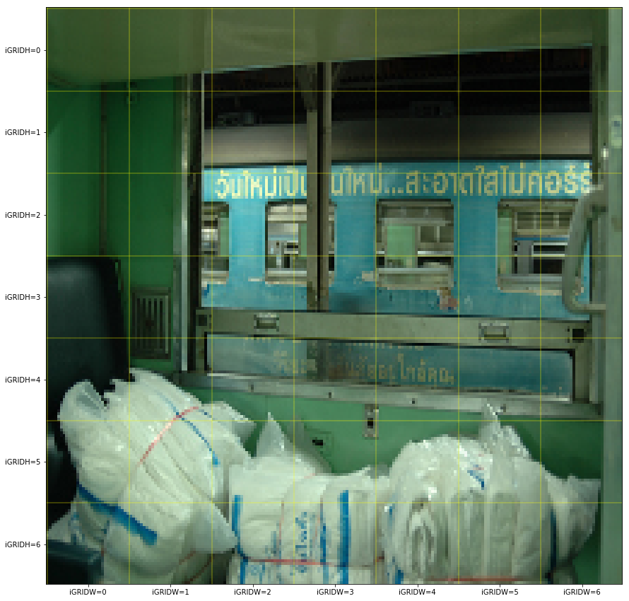

```python
def plot_image_with_grid_cell_partition(irow):
    img = x_batch[irow]
    plt.figure(figsize=(15,15))
    plt.imshow(img)
    for wh in ["W","H"]:
        GRID_       = 7
        IMAGE_      = 208
        if wh == "W":
            pltax   = plt.axvline
            plttick = plt.xticks
        else:
            pltax   = plt.axhline
            plttick = plt.yticks

        for count in range(GRID_):
            l = IMAGE_*count/GRID_
            pltax(l,color="yellow",alpha=0.3)
        plttick([(i + 0.5)*IMAGE_/GRID_ for i in range(GRID_)],
                ["iGRID{}={}".format(wh,i) for i in range(GRID_)])

def plot_grid(irow):
    import seaborn as sns
    color_palette = list(sns.xkcd_rgb.values())
    iobj = 0
    for igrid_h in range(GRID_H):
        for igrid_w in range(GRID_W):
            for ianchor in range(4):
                vec = y_batch[irow,igrid_h,igrid_w, iframe,:]
                C = vec[4] ## ground truth confidence
                if C == 1:
                    class_nm = np.array(LABELS)[np.where(vec[5:])]
                    x, y, w, h = vec[:4]
                    multx = IMAGE_W/GRID_W
                    multy = IMAGE_H/GRID_H
                    c = color_palette[iobj]
                    iobj += 1
                    xmin = x - 0.5*w
                    ymin = y - 0.5*h
                    xmax = x + 0.5*w
                    ymax = y + 0.5*h
                    # center
                    plt.text(x*multx,y*multy,
                                "X",color=c,fontsize=23)
                    plt.plot(np.array([xmin,xmin])*multx,
                                np.array([ymin,ymax])*multy,color=c,linewidth=5)
                    plt.plot(np.array([xmin,xmax])*multx,
                                np.array([ymin,ymin])*multy,color=c,linewidth=5)
                    plt.plot(np.array([xmax,xmax])*multx,
                                np.array([ymax,ymin])*multy,color=c,linewidth=5)
                    plt.plot(np.array([xmin,xmax])*multx,
                                np.array([ymax,ymax])*multy,color=c,linewidth=5)




iframe=3
IMAGE_W, IMAGE_H =(208,208)
GRID_W, GRID_H =(7,7)
plot_image_with_grid_cell_partition(iframe)
plot_grid(iframe)
plt.show()
```

## Step 3: Model Architecture

### Base Model : Resnet50

```python
from keras.applications import ResNet50
from keras.layers import Input
input_image = Input(shape=x_batch.shape[1:],name="input_image")
true_boxes  = Input(shape=(1, 1, 1, 80 , 4),name="input_hack")
base_model= ResNet50(include_top=False,weights='imagenet',input_shape= x_batch.shape[1:])

base_model.trainable = False

base_model.summary()
```

```
____________________________________________________________________________________________________
Layer (type)                     Output Shape          Param #     Connected to
====================================================================================================
input_1 (InputLayer)             (None, 208, 208, 3)   0
____________________________________________________________________________________________________
conv1 (Conv2D)                   (None, 104, 104, 64)  9472        input_1[0][0]
____________________________________________________________________________________________________
bn_conv1 (BatchNormalization)    (None, 104, 104, 64)  256         conv1[0][0]
____________________________________________________________________________________________________
activation_1 (Activation)        (None, 104, 104, 64)  0           bn_conv1[0][0]
____________________________________________________________________________________________________
max_pooling2d_1 (MaxPooling2D)   (None, 51, 51, 64)    0           activation_1[0][0]
____________________________________________________________________________________________________
res2a_branch2a (Conv2D)          (None, 51, 51, 64)    4160        max_pooling2d_1[0][0]
____________________________________________________________________________________________________
bn2a_branch2a (BatchNormalizatio (None, 51, 51, 64)    256         res2a_branch2a[0][0]
____________________________________________________________________________________________________
activation_2 (Activation)        (None, 51, 51, 64)    0           bn2a_branch2a[0][0]
____________________________________________________________________________________________________
res2a_branch2b (Conv2D)          (None, 51, 51, 64)    36928       activation_2[0][0]
____________________________________________________________________________________________________
bn2a_branch2b (BatchNormalizatio (None, 51, 51, 64)    256         res2a_branch2b[0][0]
____________________________________________________________________________________________________
activation_3 (Activation)        (None, 51, 51, 64)    0           bn2a_branch2b[0][0]
____________________________________________________________________________________________________
res2a_branch2c (Conv2D)          (None, 51, 51, 256)   16640       activation_3[0][0]
____________________________________________________________________________________________________
res2a_branch1 (Conv2D)           (None, 51, 51, 256)   16640       max_pooling2d_1[0][0]
____________________________________________________________________________________________________
bn2a_branch2c (BatchNormalizatio (None, 51, 51, 256)   1024        res2a_branch2c[0][0]
____________________________________________________________________________________________________
bn2a_branch1 (BatchNormalization (None, 51, 51, 256)   1024        res2a_branch1[0][0]
____________________________________________________________________________________________________
add_1 (Add)                      (None, 51, 51, 256)   0           bn2a_branch2c[0][0]
                                                                   bn2a_branch1[0][0]
____________________________________________________________________________________________________
activation_4 (Activation)        (None, 51, 51, 256)   0           add_1[0][0]
____________________________________________________________________________________________________
res2b_branch2a (Conv2D)          (None, 51, 51, 64)    16448       activation_4[0][0]
____________________________________________________________________________________________________
```

[output cut: 316 more lines]

```
res5c_branch2c (Conv2D)          (None, 7, 7, 2048)    1050624     activation_48[0][0]
____________________________________________________________________________________________________
bn5c_branch2c (BatchNormalizatio (None, 7, 7, 2048)    8192        res5c_branch2c[0][0]
____________________________________________________________________________________________________
add_16 (Add)                     (None, 7, 7, 2048)    0           bn5c_branch2c[0][0]
                                                                   activation_46[0][0]
____________________________________________________________________________________________________
activation_49 (Activation)       (None, 7, 7, 2048)    0           add_16[0][0]
____________________________________________________________________________________________________
avg_pool (AveragePooling2D)      (None, 1, 1, 2048)    0           activation_49[0][0]
====================================================================================================
Total params: 23,587,712
Trainable params: 0
Non-trainable params: 23,587,712
____________________________________________________________________________________________________
```

### Transfer Learning

```python
from keras.models import Sequential, Model
from keras.layers import Reshape, Activation, Conv2D, Input, MaxPooling2D, BatchNormalization, Flatten, Dense, Lambda, Dropout, SpatialDropout2D


#Code by George Seif: https://towardsdatascience.com/transfer-learning-for-image-classification-using-keras-c47ccf09c8c8

def build_finetune_model(base_model, num_classes):
    for layer in base_model.layers:
        layer.trainable = False

    x = base_model.layers[-2].output
    print(x.shape)

    #Final trainable layer
    x = Conv2D (4*(1+4+num_classes), (1,1), strides=(1,1), padding='same', name='trans_conv_4')(x)
    print(x.shape)
    output = Reshape((GRID_H, GRID_W, BOX, 4 + 1 + CLASS),name="final_output")(x)

    #without this layer, the fit_generator will receive two arrays, x_batch and b_batch.
    #That is why we add this layer and let the generator only receive what it needs: x_batch
    output = Lambda(lambda args: args[0],name="hack_layer")([output, true_boxes])


    finetune_model = Model(inputs=[base_model.input, true_boxes], outputs=output)

    return (finetune_model, true_boxes)


BOX               = int(len(ANCHORS)/2)
CLASS             = len(LABELS)
finetune_model, true_boxes = build_finetune_model(base_model,
                                      num_classes=len(LABELS))

finetune_model.summary()
```

```
(?, 7, 7, 2048)
(?, 7, 7, 100)
____________________________________________________________________________________________________
Layer (type)                     Output Shape          Param #     Connected to
====================================================================================================
input_1 (InputLayer)             (None, 208, 208, 3)   0
____________________________________________________________________________________________________
conv1 (Conv2D)                   (None, 104, 104, 64)  9472        input_1[0][0]
____________________________________________________________________________________________________
bn_conv1 (BatchNormalization)    (None, 104, 104, 64)  256         conv1[0][0]
____________________________________________________________________________________________________
activation_1 (Activation)        (None, 104, 104, 64)  0           bn_conv1[0][0]
____________________________________________________________________________________________________
max_pooling2d_1 (MaxPooling2D)   (None, 51, 51, 64)    0           activation_1[0][0]
____________________________________________________________________________________________________
res2a_branch2a (Conv2D)          (None, 51, 51, 64)    4160        max_pooling2d_1[0][0]
____________________________________________________________________________________________________
bn2a_branch2a (BatchNormalizatio (None, 51, 51, 64)    256         res2a_branch2a[0][0]
____________________________________________________________________________________________________
activation_2 (Activation)        (None, 51, 51, 64)    0           bn2a_branch2a[0][0]
____________________________________________________________________________________________________
res2a_branch2b (Conv2D)          (None, 51, 51, 64)    36928       activation_2[0][0]
____________________________________________________________________________________________________
bn2a_branch2b (BatchNormalizatio (None, 51, 51, 64)    256         res2a_branch2b[0][0]
____________________________________________________________________________________________________
activation_3 (Activation)        (None, 51, 51, 64)    0           bn2a_branch2b[0][0]
____________________________________________________________________________________________________
res2a_branch2c (Conv2D)          (None, 51, 51, 256)   16640       activation_3[0][0]
____________________________________________________________________________________________________
res2a_branch1 (Conv2D)           (None, 51, 51, 256)   16640       max_pooling2d_1[0][0]
____________________________________________________________________________________________________
bn2a_branch2c (BatchNormalizatio (None, 51, 51, 256)   1024        res2a_branch2c[0][0]
____________________________________________________________________________________________________
bn2a_branch1 (BatchNormalization (None, 51, 51, 256)   1024        res2a_branch1[0][0]
____________________________________________________________________________________________________
add_1 (Add)                      (None, 51, 51, 256)   0           bn2a_branch2c[0][0]
                                                                   bn2a_branch1[0][0]
____________________________________________________________________________________________________
activation_4 (Activation)        (None, 51, 51, 256)   0           add_1[0][0]
____________________________________________________________________________________________________
```

[output cut: 325 more lines]

```
activation_49 (Activation)       (None, 7, 7, 2048)    0           add_16[0][0]
____________________________________________________________________________________________________
trans_conv_4 (Conv2D)            (None, 7, 7, 100)     204900      activation_49[0][0]
____________________________________________________________________________________________________
final_output (Reshape)           (None, 7, 7, 4, 25)   0           trans_conv_4[0][0]
____________________________________________________________________________________________________
input_hack (InputLayer)          (None, 1, 1, 1, 80, 4 0
____________________________________________________________________________________________________
hack_layer (Lambda)              (None, 7, 7, 4, 25)   0           final_output[0][0]
                                                                   input_hack[0][0]
====================================================================================================
Total params: 23,792,612
Trainable params: 204,900
Non-trainable params: 23,587,712
____________________________________________________________________________________________________
```

### Initialize Weights

```python
def initialize_weight(layer,sd):
    weights = layer.get_weights()
    kernel = np.random.normal(size=weights[0].shape, scale=sd)
    bias   = np.random.normal(size=weights[1].shape, scale=sd)
    layer.set_weights([kernel, bias])

grid_h=7
grid_w=7

layer= finetune_model.layers[-4] # the last convolutional layer
initialize_weight(layer,sd=1/(grid_h*grid_w))
```

Below is how the final loss function will look.

**def custom_loss (y_true, y_pred):**

```
#Get Prediction
pred_xy, pred_wy, pred_conf, pred_class = get_prediction (y_pred)

#Extract Truth
true_xy, true_wy, true_conf, true_class = get_truth (y_true)

#Calculate loss for bounding boxes using *IOU
loss_bbx = calc_loss_bbx (true_xy, true_wh, pred_xy, pred_wh, true_conf)

#Calculate loss for classification
loss_class = calc_loss_class (true_class, pred_class, true_conf)



loss = loss_bbx + loss_class

return loss
```

### Get Prediction

```python
import tensorflow as tf

#Since we are dividing images into grids, we need an additional function.
def get_cell_grid(GRID_W,GRID_H,BATCH_SIZE,BOX):

    cell_x = tf.to_float(tf.reshape(tf.tile(tf.range(GRID_W), [GRID_H]), (1, GRID_H, GRID_W, 1, 1)))
    cell_y = tf.transpose(cell_x, (0,2,1,3,4))
    ## cell_gird.shape = (16, 13, 13, 5, 2)
    ## for any n, k, i, j
    ##    cell_grid[n, i, j, anchor, k] = j when k = 0
    ## for any n, k, i, j
    ##    cell_grid[n, i, j, anchor, k] = i when k = 1
    cell_grid = tf.tile(tf.concat([cell_x,cell_y], -1), [BATCH_SIZE, 1, 1, BOX, 1])
    return(cell_grid)

def get_prediction(y_pred, cell_grid):

    BOX = int(len(ANCHORS)/2)
    pred_xy = tf.sigmoid(y_pred[..., :2]) + cell_grid
    #tf.exp to get rid of negatives; -0.5 to set the value in the range of [0,grid_wh = 7]
    pred_wh = tf.exp(y_pred[..., 2:4]) * np.reshape(ANCHORS,[1,1,1,BOX,2])



    pred_conf = tf.sigmoid(y_pred[..., 4])
    pred_class = y_pred[..., 5:]

    return(pred_xy,pred_wh,pred_conf,pred_class)
```

#### Overview of the predicted data

In order to show you the overview of the prediction, codes from [experiencor's github](https://github.com/experiencor/keras-yolo2/blob/master/Yolo%20Step-by-Step.ipynb) were modified to match our calculation.

```python
def print_min_max(vec,title):

    print("{} MIN={:5.2f}, MAX={:5.2f}".format(
        title,np.min(vec),np.max(vec)))

print("*"*30)
print("prepare inputs")
BATCH_SIZE = 64
GRID_W = 7
GRID_H = 7
CLASS = len(LABELS)
size   = BATCH_SIZE*GRID_W*GRID_H*BOX*(4 + 1 + CLASS)
y_pred = np.random.normal(size=size,scale = 10/(GRID_H*GRID_W))
y_pred = y_pred.reshape(BATCH_SIZE,GRID_H,GRID_W,BOX,4 + 1 + CLASS)
print("y_pred before scaling = {}".format(y_pred.shape))

print("*"*30)
print("define tensor graph")
y_pred_tf = tf.constant(y_pred,dtype="float32")
cell_grid = get_cell_grid(GRID_W = GRID_W,GRID_H = GRID_H,BATCH_SIZE =64, BOX=BOX)

(pred_box_xy_tf,   pred_box_wh_tf,
 pred_box_conf_tf, pred_box_class_tf) = get_prediction(y_pred_tf, cell_grid)
print("*"*30 + "\nouput\n" + "*"*30)
with tf.Session() as sess:
    (pred_box_xy,   pred_box_wh,
     pred_box_conf, pred_box_class) = sess.run(
        [pred_box_xy_tf,   pred_box_wh_tf,
         pred_box_conf_tf, pred_box_class_tf])

print("\npred_box_xy {}".format(pred_box_xy.shape))
for igrid_w in range(pred_box_xy.shape[2]):
        print_min_max(pred_box_xy[:,:,igrid_w,0].flatten(),
                      "  bounding box x at iGRID_W={:02.0f}".format(igrid_w))
for igrid_h in range(pred_box_xy.shape[1]):
    print_min_max(pred_box_xy[:,igrid_h,:,1].flatten(),
                  "  bounding box y at iGRID_H={:02.0f}".format(igrid_h))

print("\npred_box_wh {}".format(pred_box_wh.shape))
print_min_max(pred_box_wh[:,:,:,0].flatten(),"  bounding box width ")
print_min_max(pred_box_wh[:,:,:,1].flatten(),"  bounding box height")

print("\npred_box_conf {}".format(pred_box_conf.shape))
print_min_max(pred_box_conf.flatten(),"  confidence ")

print("\npred_box_class {}".format(pred_box_class.shape))
print_min_max(pred_box_class.flatten(),"  class probability")
```

```
prepare inputs
y_pred before scaling = (64, 7, 7, 4, 25)
define tensor graph
ouput

pred_box_xy (64, 7, 7, 4, 2)
  bounding box x at iGRID_W=00 MIN= 0.33, MAX= 6.66
  bounding box x at iGRID_W=01 MIN= 0.38, MAX= 6.61
  bounding box x at iGRID_W=02 MIN= 0.38, MAX= 6.60
  bounding box x at iGRID_W=03 MIN= 0.40, MAX= 6.61
  bounding box x at iGRID_W=04 MIN= 0.39, MAX= 6.61
  bounding box x at iGRID_W=05 MIN= 0.38, MAX= 6.71
  bounding box x at iGRID_W=06 MIN= 0.36, MAX= 6.67
  bounding box y at iGRID_H=00 MIN= 0.33, MAX= 6.59
  bounding box y at iGRID_H=01 MIN= 0.39, MAX= 6.64
  bounding box y at iGRID_H=02 MIN= 0.39, MAX= 6.64
  bounding box y at iGRID_H=03 MIN= 0.36, MAX= 6.62
  bounding box y at iGRID_H=04 MIN= 0.37, MAX= 6.62
  bounding box y at iGRID_H=05 MIN= 0.37, MAX= 6.62
  bounding box y at iGRID_H=06 MIN= 0.40, MAX= 6.66

pred_box_wh (64, 7, 7, 4, 2)
  bounding box width  MIN= 0.28, MAX= 1.85
  bounding box height MIN= 0.69, MAX= 5.73

pred_box_conf (64, 7, 7, 4)
  confidence  MIN= 0.33, MAX= 0.69

pred_box_class (64, 7, 7, 4, 20)
  class probability MIN=-0.94, MAX= 0.88
```

### Extract Truth

```python
def get_truth(y_true):


    true_xy = y_true[...,0:2]
    true_wh = y_true[...,2:4]
    true_conf = y_true[...,4]
    true_class = tf.argmax(y_true[..., 5:], -1)
    return(true_xy, true_wh, true_conf, true_class)
```

#### Overview of the ground truth

In order to show you the overview of the ground truth data, codes from [experiencor's github](https://github.com/experiencor/keras-yolo2/blob/master/Yolo%20Step-by-Step.ipynb) were modified to match our calculation.

```python
import numpy as np
# y_batch is the output of the simpleBatchGenerator.fit()
print("Input y_batch = {}".format(y_batch.shape))

y_batch_tf = tf.constant(y_batch,dtype="float32")
(true_box_xy_tf, true_box_wh_tf,
 true_box_conf_tf, true_box_class_tf) = get_truth(y_batch_tf)

print("*"*30 + "\nouput\n" + "*"*30)

with tf.Session() as sess:
        (true_box_xy, true_box_wh,
         true_box_conf, true_box_class) = sess.run(
                    [true_box_xy_tf,   true_box_wh_tf,
                     true_box_conf_tf, true_box_class_tf])

print("\ntrue_box_xy {}".format(true_box_xy.shape))
for igrid_w in range(true_box_xy.shape[2]):
    vec  = true_box_xy[:,:,igrid_w,:,0].flatten()
    pick = true_box_conf[:,:,igrid_w,:].flatten() == 1
    bruh = vec[pick]
    if not bruh.any():
        bruh = np.zeros((208,), dtype = int)

    print_min_max(bruh,"  bounding box x at iGRID_W={:02.0f}".format(igrid_w))

for igrid_h in range(true_box_xy.shape[1]):
    vec  = true_box_xy[:,igrid_h,:,:,1].flatten()
    pick = true_box_conf[:,igrid_h,:,:].flatten() == 1
    bruh = vec[pick]
    if not bruh.any():
        bruh = np.zeros((208,), dtype = int)
    print_min_max(bruh,"  bounding box y at iGRID_H={:02.0f}".format(igrid_h))

print("\ntrue_box_wh {}".format(true_box_wh.shape))
print_min_max(true_box_wh[:,:,:,:,0].flatten(),"  bounding box width ")
print_min_max(true_box_wh[:,:,:,:,1].flatten(),"  bounding box height")

print("\ntrue_box_conf {}".format(true_box_conf.shape))
print("  confidence, unique value = {}".format(np.unique(true_box_conf.flatten())))

print("\ntrue_box_class {}".format(true_box_class.shape))
print("  class index, unique value = {}".format(np.unique(true_box_class.flatten())) )
```

```
Input y_batch = (64, 7, 7, 4, 25)
ouput

true_box_xy (64, 7, 7, 4, 2)
  bounding box x at iGRID_W=00 MIN= 0.18, MAX= 0.98
  bounding box x at iGRID_W=01 MIN= 1.06, MAX= 1.98
  bounding box x at iGRID_W=02 MIN= 2.05, MAX= 3.00
  bounding box x at iGRID_W=03 MIN= 3.00, MAX= 3.98
  bounding box x at iGRID_W=04 MIN= 4.05, MAX= 4.92
  bounding box x at iGRID_W=05 MIN= 5.04, MAX= 5.99
  bounding box x at iGRID_W=06 MIN= 6.06, MAX= 6.82
  bounding box y at iGRID_H=00 MIN= 0.91, MAX= 0.91
  bounding box y at iGRID_H=01 MIN= 1.21, MAX= 1.98
  bounding box y at iGRID_H=02 MIN= 2.03, MAX= 2.98
  bounding box y at iGRID_H=03 MIN= 3.05, MAX= 3.99
  bounding box y at iGRID_H=04 MIN= 4.02, MAX= 4.98
  bounding box y at iGRID_H=05 MIN= 5.00, MAX= 5.99
  bounding box y at iGRID_H=06 MIN= 6.11, MAX= 6.78

true_box_wh (64, 7, 7, 4, 2)
  bounding box width  MIN= 0.00, MAX= 6.99
  bounding box height MIN= 0.00, MAX= 6.99

true_box_conf (64, 7, 7, 4)
  confidence, unique value = [ 0.  1.]

true_box_class (64, 7, 7, 4)
  class index, unique value = [ 0  1  2  3  4  5  6  7  8  9 10 11 12 13 14 15 16 17 18 19]
```

### Custom Loss Function

From here, we will implement the loss function that was provided in the YOLO paper. Since this is a highly complicated coding, I referred to the codes of Hyunh and Kondo. Their works are cited here.

```python
def calc_loss_xywh(true_box_conf,

                   true_box_xy, pred_box_xy,true_box_wh,pred_box_wh):
    '''
    coord_mask:      np.array of shape (Nbatch, Ngrid h, N grid w, 1)
                     lambda_{coord} L_{i,j}^{obj}

    '''

    # lambda_{coord} L_{i,j}^{obj}
    # np.array of shape (Nbatch, Ngrid h, N grid w, N anchor, 1)
    coord_mask  = tf.expand_dims(true_box_conf, axis=-1)
    nb_coord_box = tf.reduce_sum(tf.to_float(coord_mask > 0.0))
    loss_xy      = tf.reduce_sum(tf.square(true_box_xy-pred_box_xy)* coord_mask) / (nb_coord_box + 1e-6) / 2.
    loss_wh      = tf.reduce_sum(tf.square(true_box_wh-pred_box_wh)* coord_mask) / (nb_coord_box + 1e-6) / 2.
    return(loss_xy + loss_wh, coord_mask)

loss_xywh_tf, coord_mask_tf  = calc_loss_xywh(true_box_conf_tf,
                                               true_box_xy_tf, pred_box_xy_tf,true_box_wh_tf,pred_box_wh_tf)

print("*"*30 + "\nouput\n" + "*"*30)

with tf.Session() as sess:
        loss_xywh = sess.run([loss_xywh_tf])[0]
print("loss_xywh = {:4.3f}".format(loss_xywh))
```

```
ouput
loss_xywh = 1.646
```

```python
def calc_loss_class(true_class, pred_class, true_conf):


    loss_class = tf.nn.sparse_softmax_cross_entropy_with_logits(labels=true_class, logits=pred_class)
    n_class_box = tf.reduce_sum(tf.to_float(true_conf > 0.0))

    loss_class = tf.reduce_sum(loss_class * true_conf)/(n_class_box+1e-6)

    return loss_class

loss_class_tf  = calc_loss_class(true_box_class_tf,pred_box_class_tf, true_box_conf_tf)
print("*"*30 + "\nouput\n" + "*"*30)
with tf.Session() as sess:
        loss_class = sess.run(loss_class_tf)
print("loss_class = {:4.3f}".format(loss_class))
```

```
ouput
loss_class = 3.015
```

```python
def get_iou(true_xy, true_wh, pred_xy, pred_wh):

    true_mins = true_xy - (true_wh/2)
    true_maxes = true_xy + (true_wh/2)
    pred_mins = pred_xy - (pred_wh/2)
    pred_maxes = pred_xy + (pred_wh/2)

    inter_maxes = tf.minimum(pred_maxes,true_maxes)
    inter_mins = tf.maximum(pred_mins, true_mins)
    inter_wh = tf.maximum(inter_maxes - inter_mins, 0.)
    inter_area = inter_wh[...,0] * inter_wh[...,1]

    union_area = (true_wh[...,0]*true_wh[...,1]) + (pred_wh[...,0]*pred_wh[...,1]) - inter_area
    iou = tf.truediv (inter_area, union_area)


    return iou

def calc_IOU_pred_true_assigned(true_conf,
                                true_xy, true_wh,
                                pred_xy,  pred_wh):

    iou_scores        =  get_iou(true_xy,true_wh,
                                            pred_xy,pred_wh)
    true_conf_IOU = iou_scores * true_conf
    return(true_conf_IOU)

def calc_IOU_pred_true_best(pred_xy,pred_wh, true_boxes):


    true_xy = true_boxes[..., 0:2]           # (N batch, 1, 1,  80, 2)
    true_wh = true_boxes[..., 2:4]           # (N batch, 1, 1,  80, 2)

    pred_xy = tf.expand_dims(pred_xy, 4) # (N batch, N grid_h, N grid_w, N anchor, 1, 2)
    pred_wh = tf.expand_dims(pred_wh, 4) # (N batch, N grid_h, N grid_w, N anchor, 1, 2)

    iou_scores  =  get_iou(true_xy,
                                      true_wh,
                                      pred_xy,
                                      pred_wh) # (N batch, N grid_h, N grid_w, N anchor, 50)

    print(iou_scores.shape)

    best_ious = tf.reduce_max(iou_scores, axis=4) # (N batch, N grid_h, N grid_w, N anchor)

    return(best_ious)

def get_conf_mask(best_ious, true_conf, true_conf_IOU):

    conf_mask = tf.to_float(best_ious < 0.6) * (1 - true_conf)
    # penalize the confidence of the boxes, which are reponsible for corresponding ground truth box
    conf_mask = conf_mask + true_conf_IOU * 5
    return(conf_mask)


def calc_loss_conf(conf_mask,true_conf_IOU, pred_conf):

    nb_conf_box  = tf.reduce_sum(tf.to_float(conf_mask  > 0.0))
    loss_conf    = tf.reduce_sum(tf.square(true_conf_IOU-pred_conf) * conf_mask)  / (nb_conf_box  + 1e-6) / 2.
    return(loss_conf)
```

```python
true_boxes_tf = tf.constant(b_batch,dtype="float32")
best_ious_tf = calc_IOU_pred_true_best(pred_box_xy_tf,
                                       pred_box_wh_tf, true_boxes_tf
                                       )
true_conf_IOU_tf = calc_IOU_pred_true_assigned(
                            true_box_conf_tf,
                            true_box_xy_tf, true_box_wh_tf,
                            pred_box_xy_tf,  pred_box_wh_tf)

conf_mask_tf = get_conf_mask(best_ious_tf,
                             true_box_conf_tf,
                             true_conf_IOU_tf)

loss_conf_tf = calc_loss_conf(conf_mask_tf,true_conf_IOU_tf, pred_box_conf_tf)
with tf.Session() as sess:
    loss_conf = sess.run(loss_conf_tf)

print("*"*30 + "\noutput\n" + "*"*30)
print("loss_conf = {:5.4f}".format(loss_conf))
```

```
(64, 7, 7, 4, 80)
output
loss_conf = 0.1246
```

```python
GRID_W = 7
GRID_H = 7
BATCH_SIZE = 64

def custom_loss (y_true, y_pred):

    total_recall = tf.Variable(0.)
    cell_grid   = get_cell_grid(GRID_W,GRID_H,BATCH_SIZE,BOX)
    # Get Prediction
    pred_xy, pred_wh, pred_conf, pred_class = get_prediction(y_pred,cell_grid)
    # Extract truth
    true_xy, true_wh, true_conf, true_class = get_truth(y_true)
    # Calculate loss for bounding boxes
    loss_xywh, coord_mask = calc_loss_xywh(true_conf,
                                           true_xy, pred_xy,true_wh,pred_wh)
    # Calculate loss for class classification
    loss_class  = calc_loss_class(true_class,pred_class,true_conf)
    # Calculate the IoU between predicted and true bounding box for each grid cell
    true_conf_IOU = calc_IOU_pred_true_assigned(true_conf,
                                                    true_xy, true_wh,
                                                    pred_xy, pred_wh)

    # For each predicted bounding box from grid cell,calculate the best IOU
    best_ious = calc_IOU_pred_true_best(pred_xy,pred_wh,true_boxes)

    # Calculate loss for the confidence
    conf_mask = get_conf_mask(best_ious, true_conf, true_conf_IOU)
    loss_conf = calc_loss_conf(conf_mask,true_conf_IOU, pred_conf)

    #Calculate the total loss
    loss = loss_class + loss_conf + loss_xywh




    return loss
```

#### Testing loss function

We will test our loss function by getting truth from our batch generator and prediction from NumPy random number generator.

```python
true_boxes = tf.Variable(np.zeros_like(b_batch),dtype="float32")
loss_tf    = custom_loss(y_batch_tf, y_pred_tf)
with tf.Session() as sess:
    loss = sess.run(loss_tf,
                    feed_dict = {true_boxes: b_batch})
loss
```

```
(64, 7, 7, 4, 80)
```

```
4.7862382
```

## Step 5: Training

### Compiling

2 callbacks will be in use -- Early Stopping and Model Checkpoint.

Early Stopping is to stop the training when the models seems to not improving after getting stuck somewhere. This can prevent overfitting.

Model Checkpoint allows us to save the model after every epoch.

For an optimizer, Adam was chosen.

```python
train_batch_generator = BatchGenerator(train_df, batch_size =64, grid_h=grid_h, grid_w=grid_w, LABELS=LABELS, shuffle=True)

[x_batch,b_batch],y_batch = train_batch_generator.__getitem__(idx=3)
#x_batch,y_batch = train_batch_generator.__getitem__(idx=3)
```

```python
from keras.callbacks import EarlyStopping, ModelCheckpoint
from keras.optimizers import SGD, Adam, RMSprop

dir_log = "logs/"
try:
    os.makedirs(dir_log)
except:
    pass


BATCH_SIZE   = 64

early_stop = EarlyStopping(monitor='loss',
                           min_delta=0.001,
                           patience=3,
                           mode='min',
                           verbose=1)

checkpoint = ModelCheckpoint('weights_yolo_on_voc2012.h5',
                             monitor='loss',
                             verbose=1,
                             save_best_only=True,
                             mode='min',
                             period=1)

mc = ModelCheckpoint('weights_withanchor.h5', save_weights_only=True, period=1)

optimizer = Adam(lr=0.5e-4, beta_1=0.9, beta_2=0.999, epsilon=1e-08, decay=0.000)
#optimizer = SGD(lr=1e-4, decay=0.0005, momentum=0.9)
#optimizer = RMSprop(lr=1e-4, rho=0.9, epsilon=1e-08, decay=0.0)

finetune_model.compile(loss=custom_loss, optimizer=optimizer)
```

```
(64, 7, 7, 4, 80)
```

```python
train_batch_generator = BatchGenerator(train_df, batch_size =64, grid_h=grid_h, grid_w=grid_w, LABELS=LABELS, shuffle=True)
valid_batch_generator = BatchGenerator(val_df, batch_size =64, grid_h=grid_h, grid_w=grid_w, LABELS=LABELS, shuffle=True)
```

```python
finetune_model.fit_generator(generator = train_batch_generator,
                    steps_per_epoch  = len(train_batch_generator),
                    epochs           = 50,
                    verbose          = 1,
                    #validation_data  = valid_batch_generator,
                    #validation_steps = len(valid_batch_generator) // BATCH_SIZE,
                    callbacks        = [early_stop, checkpoint, mc],
                    max_queue_size   = 3)
```

```python
finetune_model.load_weights('weights_yolo_on_voc2012.h5')
finetune_model.fit_generator(generator = train_batch_generator,
                    steps_per_epoch  = len(train_batch_generator),
                    epochs           = 50,
                    verbose          = 1,
                    #validation_data  = valid_batch_generator,
                    #validation_steps = len(valid_batch_generator),
                    callbacks        = [early_stop, checkpoint],
                    max_queue_size   = 3)
```

```
Epoch 00037: early stopping
```

```
<keras.callbacks.History at 0x7f76afd1f048>
```

## Step 6: Evaluation

Evaluation of PASCAL VOC 2012 Object Detection should be uniform with the file provided by [PACAL VOC 2012 CHALLENGE](http://host.robots.ox.ac.uk/pascal/VOC/voc2012/) since my benchmark model is based on it. However, this is a Matlab file, not a python. [Carthucho's github](https://github.com/Cartucho/mAP) provided a python version of this file. In this project, we will utilize their code to evaluate our model.

```python
def zero_inf_calc (c, maxn):
    if (c<0):
        c=0
    if (c>maxn):
        c=maxn
    return c

# This will re-encode the coordinate system (center_x, center_y, center_w, center_y) to (xmin, ymin, xmax, ymax)
def convert_yolo_coordinates_to_voc(x_c_n, y_c_n, width_n, height_n, image_width, image_height):
    ## remove normalization given the size of the image
    x_c = zero_inf_calc(float(x_c_n*image_width),image_width)
    y_c = zero_inf_calc(float(y_c_n*image_height),image_height)
    width = zero_inf_calc(float(width_n*image_width),image_width)
    height = zero_inf_calc(float(height_n*image_height),image_height)
    ## compute half width and half height
    half_width = width / 2
    half_height = height / 2

    xmin = int(x_c - half_width) + 1
    ymin = int(y_c - half_height) + 1
    xmax = int(x_c + half_width) + 1
    ymax = int(y_c + half_height) + 1
    return xmin, ymin, xmax, ymax
```

### Create detection files

First, let's load our trained weights to our model.

```python
finetune_model.load_weights("weights_yolo_on_voc2012.h5")
```

To test our model, we will use our validation dataset that was mentioned above.  
This dataset was not involved in training process, so it is fine.  
Below is our ground truth dataframe. This is the form we want our prediction to tranform to.

```python
val_df.head()
```

|  | width | height | depth | bbx_0_name | bbx_0_center_x | bbx_0_center_y | bbx_0_center_w | bbx_0_center_h | bbx_1_name | bbx_1_center_x | ... | bbx_54_name | bbx_54_center_x | bbx_54_center_y | bbx_54_center_w | bbx_54_center_h | bbx_55_name | bbx_55_center_x | bbx_55_center_y | bbx_55_center_w | bbx_55_center_h |
| --- | --- | --- | --- | --- | --- | --- | --- | --- | --- | --- | --- | --- | --- | --- | --- | --- | --- | --- | --- | --- | --- |
| 1 | 208 | 208 | 3 | person | 3.941000 | 4.552083 | 1.946000 | 4.895833 | person | 5.320 | ... | NaN | NaN | NaN | NaN | NaN | NaN | NaN | NaN | NaN | NaN |
| 3 | 208 | 208 | 3 | bird | 3.640751 | 3.164000 | 2.402145 | 2.632000 | NaN | NaN | ... | NaN | NaN | NaN | NaN | NaN | NaN | NaN | NaN | NaN | NaN |
| 7 | 208 | 208 | 3 | car | 5.607000 | 1.799373 | 2.786000 | 3.554859 | car | 0.945 | ... | NaN | NaN | NaN | NaN | NaN | NaN | NaN | NaN | NaN | NaN |
| 17 | 208 | 208 | 3 | bus | 3.598000 | 3.080000 | 6.804000 | 3.434667 | NaN | NaN | ... | NaN | NaN | NaN | NaN | NaN | NaN | NaN | NaN | NaN | NaN |
| 21 | 208 | 208 | 3 | chair | 1.568000 | 5.730667 | 1.204000 | 1.642667 | diningtable | 2.422 | ... | NaN | NaN | NaN | NaN | NaN | NaN | NaN | NaN | NaN | NaN |

5 rows × 285 columns

Let's create .txt files to store prediction values for each class

```python
for label in LABELS:
    file = open("/home/ubuntu/VOCdevkit/VOC2012/ImageSets/Main/"+label+"_det.txt","w")
    file.close()
```

The code below converts raw values from model.predict() to xy coordinates, confidence that range between 0 and 1, and classification. YOLO has its own specific shape of input and output, and the code by [Yumi's github](https://github.com/FairyOnIce/ObjectDetectionYolo/blob/master/Part%206%20Object%20Detection%20with%20Yolo%20using%20VOC%202012%20data%20-%20inference%20on%20image.ipynb) successfully encypher the raw data to actual pixel coordinates that we can utilize.

```python
class OutputRescaler(object):
    def __init__(self,ANCHORS):
        self.ANCHORS = ANCHORS

    def _sigmoid(self, x):
        return 1. / (1. + np.exp(-x))
    def _softmax(self, x, axis=-1, t=-100.):
        x = x - np.max(x)

        if np.min(x) < t:
            x = x/np.min(x)*t

        e_x = np.exp(x)
        return e_x / e_x.sum(axis, keepdims=True)
    def get_shifting_matrix(self,netout):

        GRID_H, GRID_W, BOX = netout.shape[:3]
        no = netout[...,0]

        ANCHORSw = self.ANCHORS[::2]
        ANCHORSh = self.ANCHORS[1::2]

        mat_GRID_W = np.zeros_like(no)
        for igrid_w in range(GRID_W):
            mat_GRID_W[:,igrid_w,:] = igrid_w

        mat_GRID_H = np.zeros_like(no)
        for igrid_h in range(GRID_H):
            mat_GRID_H[igrid_h,:,:] = igrid_h

        mat_ANCHOR_W = np.zeros_like(no)
        for ianchor in range(BOX):
            mat_ANCHOR_W[:,:,ianchor] = ANCHORSw[ianchor]

        mat_ANCHOR_H = np.zeros_like(no)
        for ianchor in range(BOX):
            mat_ANCHOR_H[:,:,ianchor] = ANCHORSh[ianchor]
        return(mat_GRID_W,mat_GRID_H,mat_ANCHOR_W,mat_ANCHOR_H)

    def fit(self, netout):
        '''
        netout  : np.array of shape (N grid h, N grid w, N anchor, 4 + 1 + N class)

        a single image output of model.predict()
        '''
        GRID_H, GRID_W, BOX = netout.shape[:3]

        (mat_GRID_W,
         mat_GRID_H,
         mat_ANCHOR_W,
         mat_ANCHOR_H) = self.get_shifting_matrix(netout)


        # bounding box parameters
        netout[..., 0]   = (self._sigmoid(netout[..., 0]) + mat_GRID_W)/GRID_W # x      unit: range between 0 and 1
        netout[..., 1]   = (self._sigmoid(netout[..., 1]) + mat_GRID_H)/GRID_H # y      unit: range between 0 and 1
        netout[..., 2]   = (np.exp(netout[..., 2]) * mat_ANCHOR_W)/GRID_W      # width  unit: range between 0 and 1
        netout[..., 3]   = (np.exp(netout[..., 3]) * mat_ANCHOR_H)/GRID_H      # height unit: range between 0 and 1
        # rescale the confidence to range 0 and 1
        netout[..., 4]   = self._sigmoid(netout[..., 4])
        expand_conf      = np.expand_dims(netout[...,4],-1) # (N grid h , N grid w, N anchor , 1)
        # rescale the class probability to range between 0 and 1
        # Pr(object class = k) = Pr(object exists) * Pr(object class = k |object exists)
        #                      = Conf * P^c
        netout[..., 5:]  = expand_conf * self._softmax(netout[..., 5:])
        # ignore the class probability if it is less than obj_threshold

        return(netout)
```

### Warning: Below will take longer than expected!

What is done below is creating a detection file for each class. Iterating through the validation dataframe, we find images with matching fileID. We, then, get y_pred for each image, find all the predicted boxes, and save them in each different file with different labels.  
**WriteFile function** is pretty self-explanatory; it writes down the info in a form of (filename, confidence, xmin, ymin, xmax, ymax). This is so that we can utitlize the evalution function provided by Bharath Hariharan (below the following code block).  
**DistributeInfo function** goes through each grid cell and extracts the information of the bounding boxes. Then, it sends the information to WriteFile function to save.

```python
def WriteFile (filename, label, confidence, xmin, ymin, xmax, ymax):
    file = open("/home/ubuntu/VOCdevkit/VOC2012/ImageSets/Main/"+label+"_det.txt","a+")

    file.write(filename+" "+str(confidence)+" "+str(xmin)+" "+str(ymin)+" "+str(xmax)+" "+str(ymax)+"\n")

    file.close()

def DistributeInfo(netout_scale, filename, threshold):
    GRID_H, GRID_W, BOX = netout_scale.shape[:3]
    for row in range(GRID_H):
        for col in range(GRID_W):
            for b in range(BOX):
                # from 4th element onwards are confidence and class classes
                classes = netout_scale[row,col,b,5:]
                if np.sum(classes) > 0:
                    label_idx = np.argmax(classes)
                    label = LABELS[label_idx]
                    # first 4 elements are x, y, w, and h
                    x, y, w, h = netout_scale[row,col,b,:4]
                    confidence = netout_scale[row,col,b,4]
                    box = BoundingBox (w,h, confidence, classes)
                    if confidence>threshold:
                        xmin, ymin, xmax, ymax = convert_yolo_coordinates_to_voc(x, y, w, h, 208, 208)
                        WriteFile(filename, label, confidence, xmin, ymin, xmax, ymax)
                    else:
                        continue



for i, (index, row) in enumerate(val_df.iterrows()):
    filename = row["fileID"]+".jpg"
    filepath = "/home/ubuntu/VOCdevkit/VOC2012/JPEGImages/"+filename
    img=rescale_img(208, 208, filepath)
    x_test_batch = np.expand_dims(img,0)
    dummy_array = np.zeros((1,1,1,1,80,4))
    # Because our batch generator has two outputs: x_batch and b_batch,
    y_pred = finetune_model.predict([x_test_batch,dummy_array])
    netout         = y_pred[0]
    outputRescaler = OutputRescaler(ANCHORS=ANCHORS)
    netout_scale   = outputRescaler.fit(netout)
    DistributeInfo(netout_scale, filename, threshold = 0.03)
```

```
/usr/local/lib/python3.5/dist-packages/ipykernel_launcher.py:6: RuntimeWarning: overflow encountered in exp
```

### Calculate Average Precision for each class

Now we need to calculate AP for each class by the method provided by PASCAL VOC 2012 CHALLENGE. The code below is a python version of .m file provided by PASCAL VOC 2012 CHALLENGE for evaluation method. [AlexeyAB's github](https://github.com/AlexeyAB/darknet/blob/master/scripts/voc_eval_py3.py) provides the code below that is originally written by Bharath Hariharan.

```python
# --------------------------------------------------------
# Fast/er R-CNN
# Licensed under The MIT License
# Written by Bharath Hariharan
# --------------------------------------------------------

import xml.etree.ElementTree as ET
import os
#import cPickle
import _pickle as cPickle
import numpy as np

def parse_rec(filename):
    """ Parse a PASCAL VOC xml file """
    tree = ET.parse(filename)
    objects = []
    for obj in tree.findall('object'):
        obj_struct = {}
        obj_struct['name'] = obj.find('name').text
        #obj_struct['pose'] = obj.find('pose').text
        #obj_struct['truncated'] = int(obj.find('truncated').text)
        obj_struct['difficult'] = int(obj.find('difficult').text)
        bbox = obj.find('bndbox')
        obj_struct['bbox'] = [int(bbox.find('xmin').text),
                              int(bbox.find('ymin').text),
                              int(bbox.find('xmax').text),
                              int(bbox.find('ymax').text)]
        objects.append(obj_struct)

    return objects

def voc_ap(rec, prec, use_07_metric=False):
    """ ap = voc_ap(rec, prec, [use_07_metric])
    Compute VOC AP given precision and recall.
    If use_07_metric is true, uses the
    VOC 07 11 point method (default:False).
    """
    if use_07_metric:
        # 11 point metric
        ap = 0.
        for t in np.arange(0., 1.1, 0.1):
            if np.sum(rec >= t) == 0:
                p = 0
            else:
                p = np.max(prec[rec >= t])
            ap = ap + p / 11.
    else:
        # correct AP calculation
        # first append sentinel values at the end
        mrec = np.concatenate(([0.], rec, [1.]))
        mpre = np.concatenate(([0.], prec, [0.]))

        # compute the precision envelope
        for i in range(mpre.size - 1, 0, -1):
            mpre[i - 1] = np.maximum(mpre[i - 1], mpre[i])

        # to calculate area under PR curve, look for points
        # where X axis (recall) changes value
        i = np.where(mrec[1:] != mrec[:-1])[0]

        # and sum (\Delta recall) * prec
        ap = np.sum((mrec[i + 1] - mrec[i]) * mpre[i + 1])
    return ap

def voc_eval(detpath,
             annopath,
             imagesetfile,
             classname,
             cachedir,
             ovthresh=0.3,
             use_07_metric=False):
    """rec, prec, ap = voc_eval(detpath,
                                annopath,
                                imagesetfile,
                                classname,
                                [ovthresh],
                                [use_07_metric])
    Top level function that does the PASCAL VOC evaluation.
    detpath: Path to detections
        detpath.format(classname) should produce the detection results file.
    annopath: Path to annotations
        annopath.format(imagename) should be the xml annotations file.
    imagesetfile: Text file containing the list of images, one image per line.
    classname: Category name (duh)
    cachedir: Directory for caching the annotations
    [ovthresh]: Overlap threshold (default = 0.5)
    [use_07_metric]: Whether to use VOC07's 11 point AP computation
        (default False)
    """
    # assumes detections are in detpath.format(classname)
    # assumes annotations are in annopath.format(imagename)
    # assumes imagesetfile is a text file with each line an image name
    # cachedir caches the annotations in a pickle file

    # first load gt
    if not os.path.isdir(cachedir):
        os.mkdir(cachedir)
    cachefile = os.path.join(cachedir, 'annots.pkl')
    # read list of images
    with open(imagesetfile, 'r') as f:
        lines = f.readlines()
    imagenames = [x.strip() for x in lines]


    if not os.path.isfile(cachefile):
        # load annots
        recs = {}
        for i, imagename in enumerate(imagenames):
            imagename = imagename.split()[0]
            recs[imagename] = parse_rec(annopath+imagename+".xml")#annopath.format(imagename) was changed to annopath + imagename+".xml"
            if i % 100 == 0:
                print('Reading annotation for {:d}/{:d}'.format(i + 1, len(imagenames)))
        # save
        #print('Saving cached annotations to {:s}').format(cachefile)
        with open(cachefile, 'wb') as f:
            cPickle.dump(recs, f)
    else:
        # load
        print('!!! cachefile = ',cachefile)
        with open(cachefile, 'rb') as f:
            recs = cPickle.load(f)

    # extract gt objects for this class
    class_recs = {}
    npos = 0
    for imagename in imagenames:
        imagename = imagename.split()[0]
        R = [obj for obj in recs[imagename] if obj['name'] == classname]
        bbox = np.array([x['bbox'] for x in R])
        difficult = np.array([x['difficult'] for x in R]).astype(np.bool)
        det = [False] * len(R)
        npos = npos + sum(~difficult)
        class_recs[imagename] = {'bbox': bbox,
                                 'difficult': difficult,
                                 'det': det}

    # read dets
    detfile = detpath+classname+"_det.txt" #detfile.format(classname) was changed to detpath+classname+"_det.txt"
    with open(detfile, 'r') as f:
        lines = f.readlines()


    splitlines = [x.strip().split() for x in lines]
    image_ids = [x[0].split('.')[0] for x in splitlines]

    confidence = np.array([float(x[1]) for x in splitlines])
    BB = np.array([[float(z) for z in x[2:]] for x in splitlines])
    # sort by confidence
    sorted_ind = np.argsort(-confidence)
    sorted_scores = np.sort(-confidence)
    BB = BB[sorted_ind, :]
    image_ids = [image_ids[x] for x in sorted_ind]
    # go down dets and mark TPs and FPs
    nd = len(image_ids)
    tp = np.zeros(nd)
    fp = np.zeros(nd)

    for d in range(nd):


        R = class_recs[image_ids[d]]
        bb = BB[d, :].astype(float)
        ovmax = -np.inf
        BBGT = R['bbox'].astype(float)
        if (d==0):
            PlotExample(bb, image_ids[d])

        if BBGT.size > 0:
            # compute overlaps
            # intersection
            ixmin = np.maximum(BBGT[:, 0], bb[0])
            iymin = np.maximum(BBGT[:, 1], bb[1])
            ixmax = np.minimum(BBGT[:, 2], bb[2])
            iymax = np.minimum(BBGT[:, 3], bb[3])
            iw = np.maximum(ixmax - ixmin + 1., 0.)
            ih = np.maximum(iymax - iymin + 1., 0.)
            inters = iw * ih

            # union
            uni = ((bb[2] - bb[0] + 1.) * (bb[3] - bb[1] + 1.) +
                   (BBGT[:, 2] - BBGT[:, 0] + 1.) *
                   (BBGT[:, 3] - BBGT[:, 1] + 1.) - inters)

            overlaps = inters / uni
            ovmax = np.max(overlaps)
            jmax = np.argmax(overlaps)

        if ovmax > ovthresh:
            if not R['difficult'][jmax]:
                if not R['det'][jmax]:
                    tp[d] = 1.
                    R['det'][jmax] = 1
                else:
                    fp[d] = 1.
        else:
            fp[d] = 1.

    # compute precision recall
    fp = np.cumsum(fp)
    tp = np.cumsum(tp)
    rec = tp / float(npos)
    # avoid divide by zero in case the first detection matches a difficult
    # ground truth
    prec = tp / np.maximum(tp + fp, np.finfo(np.float64).eps)
    ap = voc_ap(rec, prec, use_07_metric)

    return rec, prec, ap
```

### Plot the prediction

```python
def PlotExample(bb, imgname):
    imgpath = "/home/ubuntu/VOCdevkit/VOC2012/JPEGImages/"+imgname+".jpg"
    image = rescale_img(208, 208, imgpath )
    plt.imshow(image) # plot image
    plt_rectangle(plt,
                 label = "object",
                 x1 = bb[0],
                 y1 = bb[1],
                 x2 = bb[2],
                 y2 = bb[3])
    plt.show() ## show the plot
```

```python
detpath = "/home/ubuntu/VOCdevkit/VOC2012/ImageSets/Main/"
annopath = "/home/ubuntu/VOCdevkit/VOC2012/Annotations/"
cachedir= "/home/ubuntu/VOCdevkit/VOC2012/"
results_files_path= "/home/ubuntu/VOCdevkit/"
```

### Calculate mAP and plot one example per class

```
aeroplane
!!! cachefile =  /home/ubuntu/VOCdevkit/VOC2012/annots.pkl
```

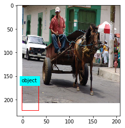

```
ap is =  7.0389174708e-07
bicycle
!!! cachefile =  /home/ubuntu/VOCdevkit/VOC2012/annots.pkl
```

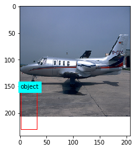

```
ap is =  0.0
bird
!!! cachefile =  /home/ubuntu/VOCdevkit/VOC2012/annots.pkl
```

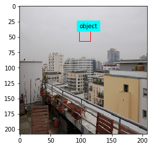

```
ap is =  1.90674564661e-07
boat
!!! cachefile =  /home/ubuntu/VOCdevkit/VOC2012/annots.pkl
```

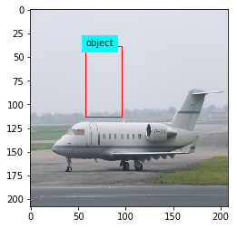

```
ap is =  8.97772480532e-06
bottle
!!! cachefile =  /home/ubuntu/VOCdevkit/VOC2012/annots.pkl
```

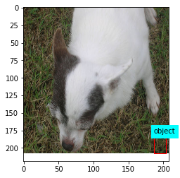

```
ap is =  0.0
bus
!!! cachefile =  /home/ubuntu/VOCdevkit/VOC2012/annots.pkl
```

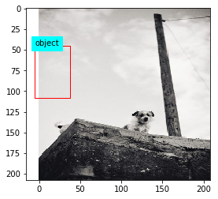

```
ap is =  2.1433929911e-06
car
!!! cachefile =  /home/ubuntu/VOCdevkit/VOC2012/annots.pkl
```

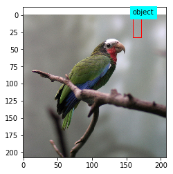

```
ap is =  3.58830444437e-06
cat
!!! cachefile =  /home/ubuntu/VOCdevkit/VOC2012/annots.pkl
```

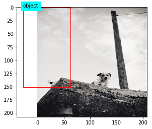

```
ap is =  0.0
chair
!!! cachefile =  /home/ubuntu/VOCdevkit/VOC2012/annots.pkl
```

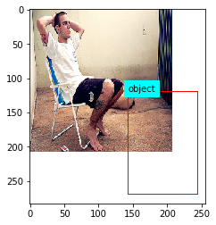

```
ap is =  6.58773404069e-06
cow
!!! cachefile =  /home/ubuntu/VOCdevkit/VOC2012/annots.pkl
```

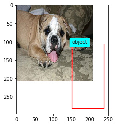

```
ap is =  1.94814218499e-05
diningtable
!!! cachefile =  /home/ubuntu/VOCdevkit/VOC2012/annots.pkl
```

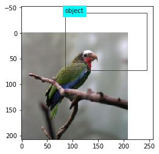

```
ap is =  0.0
dog
!!! cachefile =  /home/ubuntu/VOCdevkit/VOC2012/annots.pkl
```

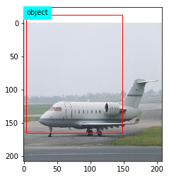

```
ap is =  1.54321490083e-05
horse
!!! cachefile =  /home/ubuntu/VOCdevkit/VOC2012/annots.pkl
```

[8 more figures not shown]

```
ap is =  0.0
sum_ap is: 6.92148383206e-05
```

```python
with open(results_files_path + "results.txt", 'w') as results_file:
    results_file.write("# AP and precision/recall per class\n")
    sum_ap = 0.0
    ap_dictionary={}
    for classname in LABELS:
        print(classname)
        imagesetfile = "/home/ubuntu/VOCdevkit/VOC2012/ImageSets/Main/" + classname + "_val.txt"
        rec, prec, ap = (voc_eval(detpath,
                         annopath,
                         imagesetfile,
                         classname = classname,
                         cachedir=cachedir,
                         ovthresh=0.5,
                         use_07_metric=False))
        sum_ap+=ap
        results_file.write(classname +
                           "\n Precision: " + str(prec) +
                           "\n Recall :" + str(rec) +
                           "\n AP :" + str(ap) +
                           "\n\n")
        ap_dictionary[classname] = ap
        print("ap is = ", ap)

print("sum_ap is:" , sum_ap)
mAP = sum_ap / len(LABELS)
```

### Visualzing the Result

With help of [Cartucho's github](https://github.com/Cartucho/mAP/blob/master/main.py), I visualized AP score for each class and ordered them in descending order. You can explore more of Cartucho's work down at Reference chapter.

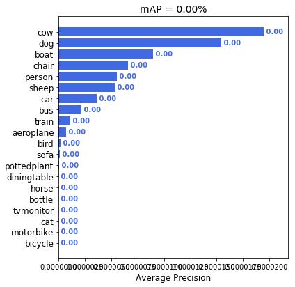

```python
import operator
def adjust_axes(r, t, fig, axes):
    # get text width for re-scaling
    bb = t.get_window_extent(renderer=r)
    text_width_inches = bb.width / fig.dpi
    # get axis width in inches
    current_fig_width = fig.get_figwidth()
    new_fig_width = current_fig_width + text_width_inches
    propotion = new_fig_width / current_fig_width
    # get axis limit
    x_lim = axes.get_xlim()
    axes.set_xlim([x_lim[0], x_lim[1]*propotion])

def draw_plot_func(dictionary, n_classes, window_title, plot_title, x_label, output_path, to_show, plot_color, true_p_bar):
    # sort the dictionary by decreasing value, into a list of tuples
    sorted_dic_by_value = sorted(dictionary.items(), key=operator.itemgetter(1))
    # unpacking the list of tuples into two lists
    sorted_keys, sorted_values = zip(*sorted_dic_by_value)
    #
    if true_p_bar != "":
        """
         Special case to draw in:
            - green -> TP: True Positives (object detected and matches ground-truth)
            - red -> FP: False Positives (object detected but does not match ground-truth)
            - orange -> FN: False Negatives (object not detected but present in the ground-truth)
        """
        fp_sorted = []
        tp_sorted = []
        for key in sorted_keys:
            fp_sorted.append(dictionary[key] - true_p_bar[key])
            tp_sorted.append(true_p_bar[key])
        plt.barh(range(n_classes), fp_sorted, align='center', color='crimson', label='False Positive')
        plt.barh(range(n_classes), tp_sorted, align='center', color='forestgreen', label='True Positive', left=fp_sorted)
        # add legend
        plt.legend(loc='lower right')
        """
         Write number on side of bar
        """
        fig = plt.gcf() # gcf - get current figure
        axes = plt.gca()
        r = fig.canvas.get_renderer()
        for i, val in enumerate(sorted_values):
            fp_val = fp_sorted[i]
            tp_val = tp_sorted[i]
            fp_str_val = " " + str(fp_val)
            tp_str_val = fp_str_val + " " + str(tp_val)
            # trick to paint multicolor with offset:
            # first paint everything and then repaint the first number
            t = plt.text(val, i, tp_str_val, color='forestgreen', va='center', fontweight='bold')
            plt.text(val, i, fp_str_val, color='crimson', va='center', fontweight='bold')
            if i == (len(sorted_values)-1): # largest bar
                adjust_axes(r, t, fig, axes)
    else:
        plt.barh(range(n_classes), sorted_values, color=plot_color)
        """
         Write number on side of bar
        """
        fig = plt.gcf() # gcf - get current figure
        axes = plt.gca()
        r = fig.canvas.get_renderer()
        for i, val in enumerate(sorted_values):
            str_val = " " + str(val) # add a space before
            if val < 1.0:
                str_val = " {0:.2f}".format(val)
            t = plt.text(val, i, str_val, color=plot_color, va='center', fontweight='bold')
            # re-set axes to show number inside the figure
            if i == (len(sorted_values)-1): # largest bar
                adjust_axes(r, t, fig, axes)
    # set window title
    fig.canvas.set_window_title(window_title)
    # write classes in y axis
    tick_font_size = 12
    plt.yticks(range(n_classes), sorted_keys, fontsize=tick_font_size)
    """
     Re-scale height accordingly
    """
    init_height = fig.get_figheight()
    # comput the matrix height in points and inches
    dpi = fig.dpi
    height_pt = n_classes * (tick_font_size * 1.4) # 1.4 (some spacing)
    height_in = height_pt / dpi
    # compute the required figure height
    top_margin = 0.15 # in percentage of the figure height
    bottom_margin = 0.05 # in percentage of the figure height
    figure_height = height_in / (1 - top_margin - bottom_margin)
    # set new height
    if figure_height > init_height:
        fig.set_figheight(figure_height)

    # set plot title
    plt.title(plot_title, fontsize=14)
    # set axis titles
    # plt.xlabel('classes')
    plt.xlabel(x_label, fontsize='large')
    # adjust size of window
    fig.tight_layout()
    # save the plot
    fig.savefig(output_path)
    # show image
    if to_show:
        plt.show()
    # close the plot
    plt.close()

window_title = "mAP"
plot_title = "mAP = {0:.2f}%".format(mAP*100)
n_classes = len(LABELS)
x_label = "Average Precision"
output_path = results_files_path + "/mAP.png"
to_show = True
plot_color = 'royalblue'
draw_plot_func(
        ap_dictionary,
        n_classes,
        window_title,
        plot_title,
        x_label,
        output_path,
        to_show,
        plot_color,
        ""
        )
```

## Step 7: References

- Alexy AB, 2019, https://github.com/AlexeyAB/darknet/blob/master/README.md#how-to-train-with-multi-gpu

  ```
                           YOLO LICENSE
                      Version 2, July 29 2016
  ```

THIS SOFTWARE LICENSE IS PROVIDED "ALL CAPS" SO THAT YOU KNOW IT IS SUPER SERIOUS AND YOU DON'T MESS AROUND WITH COPYRIGHT LAW BECAUSE YOU WILL GET IN TROUBLE HERE ARE SOME OTHER BUZZWORDS COMMONLY IN THESE THINGS WARRANTIES LIABILITY CONTRACT TORT LIABLE CLAIMS RESTRICTION MERCHANTABILITY. NOW HERE'S THE REAL LICENSE:

```
0. Darknet is public domain.
1. Do whatever you want with it.
2. Stop emailing me about it!
```

- João Cartucho, Cartucho, 2019, https://github.com/Cartucho/mAP
- Ngoc Anh Huynh, experioncer, 2018, https://github.com/experiencor/keras-yolo2,

MIT License

Copyright (c) 2017 Ngoc Anh Huynh

Permission is hereby granted, free of charge, to any person obtaining a copy of this software and associated documentation files (the "Software"), to deal in the Software without restriction, including without limitation the rights to use, copy, modify, merge, publish, distribute, sublicense, and/or sell copies of the Software, and to permit persons to whom the Software is furnished to do so, subject to the following conditions:

The above copyright notice and this permission notice shall be included in all copies or substantial portions of the Software.

THE SOFTWARE IS PROVIDED "AS IS", WITHOUT WARRANTY OF ANY KIND, EXPRESS OR IMPLIED, INCLUDING BUT NOT LIMITED TO THE WARRANTIES OF MERCHANTABILITY, FITNESS FOR A PARTICULAR PURPOSE AND NONINFRINGEMENT. IN NO EVENT SHALL THE AUTHORS OR COPYRIGHT HOLDERS BE LIABLE FOR ANY CLAIM, DAMAGES OR OTHER LIABILITY, WHETHER IN AN ACTION OF CONTRACT, TORT OR OTHERWISE, ARISING FROM, OUT OF OR IN CONNECTION WITH THE SOFTWARE OR THE USE OR OTHER DEALINGS IN THE SOFTWARE.

- Yumi Kondo, FairyOnIce, 2019, https://github.com/FairyOnIce/ObjectDetectionYolo